# Midterm Project TA

Dani Alday, Joey Clancy

# 1 Project Goal

The goal of this project is to understand the transactions of the Office Mate online store. We will examine several variables such as revenue and profits and their relationship to product variables in order to improve profitability. At the end of the project, we will provide two recommendations in a memo form for Quian Xu.

# 2 Data Preprocessing

```r
# Load all necessary packages below
library(ggplot2)
library(dplyr)
library(lubridate)
library(patchwork)
library(kableExtra)
library(forcats)
library(colorspace)
library(gridExtra)
```

```r
# Remove scientific notation
options(scipen=999)
```

```r
# Load the data
officeMate <- read.csv("mtp_off_mate.csv", header = TRUE)
```

```r
# Create cost column
officeMate <- cbind(officeMate, Cost = officeMate$Revenue - officeMate$Profit)
```

```r
# Convert necessary variables to factors
names = c("Ship.Mode", "City", "State", "Region", "Segment", "Category", "Sub.Category", "Quantity")
officeMate[names] <- lapply(officeMate[names], factor)
```

```r
# Convert dates to date type
officeMate$Order.Date <- mdy(officeMate$Order.Date)
officeMate$Ship.Date <- mdy(officeMate$Ship.Date)

# Create shipping time variable
officeMate <- cbind(officeMate, shipTime = officeMate$Ship.Date - officeMate$Order.Date)
officeMate$shipTime <- as.numeric(officeMate$shipTime, units = "days")
```

# 3 Univariate Non-Graphical Analysis

```r
# Return the first few rows of data
head(officeMate)
```

```
##         Order.ID Order.Date  Ship.Date      Ship.Mode Customer.ID
## 1 CA-2014-152156 2014-11-09 2014-11-12   Second Class    CG-12520
## 2 CA-2014-152156 2014-11-09 2014-11-12   Second Class    CG-12520
## 3 CA-2014-138688 2014-06-13 2014-06-17   Second Class    DV-13045
## 4 US-2013-108966 2013-10-11 2013-10-18 Standard Class    SO-20335
## 5 US-2013-108966 2013-10-11 2013-10-18 Standard Class    SO-20335
## 6 CA-2012-115812 2012-06-09 2012-06-14 Standard Class    BH-11710
##              City      State Postal.Code Region      Product.ID
## 1       Henderson   Kentucky       42420  South FUR-BO-10001798
## 2       Henderson   Kentucky       42420  South FUR-CH-10000454
## 3     Los Angeles California       90036   West OFF-LA-10000240
## 4 Fort Lauderdale    Florida       33311  South FUR-TA-10000577
## 5 Fort Lauderdale    Florida       33311  South OFF-ST-10000760
## 6     Los Angeles California       90032   West FUR-FU-10001487
##                                                       Product.Name   Segment
```

[output cut: 20 more lines]

**Comments**

- Data seems to be tidy
  - no duplicate columns
  - each row is an observation of a specific product from an order
  - OrderID and CustomerID are not unique

```r
# Showing the type of variables in our data set
str(officeMate)
```

```
## 'data.frame':    9994 obs. of  20 variables:
##  $ Order.ID    : chr  "CA-2014-152156" "CA-2014-152156" "CA-2014-138688" "US-2013-108966" ...
##  $ Order.Date  : Date, format: "2014-11-09" "2014-11-09" ...
##  $ Ship.Date   : Date, format: "2014-11-12" "2014-11-12" ...
##  $ Ship.Mode   : Factor w/ 4 levels "First Class",..: 3 3 3 4 4 4 4 4 4 4 ...
##  $ Customer.ID : chr  "CG-12520" "CG-12520" "DV-13045" "SO-20335" ...
##  $ City        : Factor w/ 531 levels "Aberdeen","Abilene",..: 195 195 267 154 154 267 267 267 267 267 ...
##  $ State       : Factor w/ 49 levels "Alabama","Arizona",..: 16 16 4 9 9 4 4 4 4 4 ...
##  $ Postal.Code : int  42420 42420 90036 33311 33311 90032 90032 90032 90032 90032 ...
##  $ Region      : Factor w/ 4 levels "Central","East",..: 3 3 4 3 3 4 4 4 4 4 ...
##  $ Product.ID  : chr  "FUR-BO-10001798" "FUR-CH-10000454" "OFF-LA-10000240" "FUR-TA-10000577" ...
##  $ Product.Name: chr  "Bush Somerset Collection Bookcase" "Hon Deluxe Fabric Upholstered Stacking Chairs, Rounded Back" "Self-Adhesive Address Labels for Typewriters by Universal" "Bretford CR4500 Series Slim Rectangular Table" ...
##  $ Segment     : Factor w/ 3 levels "Consumer","Corporate",..: 1 1 2 1 1 1 1 1 1 1 ...
##  $ Category    : Factor w/ 3 levels "Furniture","Office Supplies",..: 1 1 2 1 2 1 2 3 2 2 ...
##  $ Sub.Category: Factor w/ 17 levels "Accessories",..: 5 6 11 17 15 10 3 14 4 2 ...
##  $ Revenue     : num  262 731.9 14.6 957.6 22.4 ...
##  $ Quantity    : Factor w/ 14 levels "1","2","3","4",..: 2 3 2 5 2 7 4 6 3 5 ...
##  $ Discount    : num  0 0 0 0.45 0.2 0 0 0.2 0.2 0 ...
##  $ Profit      : num  41.91 219.58 6.87 -383.03 2.52 ...
##  $ Cost        : num  220.05 512.36 7.75 1340.61 19.85 ...
##  $ shipTime    : num  3 3 4 7 7 5 5 5 5 5 ...
```

**Comments**

- Data consists of numerics and integers
- Some changes should be made to the set
  - Some variables need to be converted to factor variables
  - Date columns needs to be converted to proper type
  - Added a cost column to analyze

```r
# Getting a summary of our variables
summary(officeMate)
```

```
##    Order.ID           Order.Date           Ship.Date
##  Length:9994        Min.   :2012-01-04   Min.   :2012-01-08
##  Class :character   1st Qu.:2013-05-23   1st Qu.:2013-05-27
##  Mode  :character   Median :2014-06-27   Median :2014-06-30
##                     Mean   :2014-05-01   Mean   :2014-05-04
##                     3rd Qu.:2015-05-15   3rd Qu.:2015-05-19
##                     Max.   :2015-12-31   Max.   :2016-01-06
##
##           Ship.Mode    Customer.ID                   City
##  First Class   :1538   Length:9994        New York City: 915
##  Same Day      : 543   Class :character   Los Angeles  : 747
##  Second Class  :1945   Mode  :character   Philadelphia : 537
##  Standard Class:5968                      San Francisco: 510
##                                           Seattle      : 428
##                                           Houston      : 377
##                                           (Other)      :6480
##           State       Postal.Code        Region      Product.ID
##  California  :2001   Min.   : 1040   Central:2323   Length:9994
##  New York    :1128   1st Qu.:23223   East   :2848   Class :character
##  Texas       : 985   Median :56431   South  :1620   Mode  :character
##  Pennsylvania: 587   Mean   :55190   West   :3203
##  Washington  : 506   3rd Qu.:90008
##  Illinois    : 492   Max.   :99301
##  (Other)     :4295
##  Product.Name              Segment                Category
##  Length:9994        Consumer   :5191   Furniture      :2121
##  Class :character   Corporate  :3020   Office Supplies:6026
##  Mode  :character   Home Office:1783   Technology     :1847
##
##
##
##
##       Sub.Category     Revenue             Quantity       Discount
##  Binders    :1523   Min.   :    0.444   3      :2409   Min.   :0.0000
##  Paper      :1370   1st Qu.:   17.280   2      :2402   1st Qu.:0.0000
##  Furnishings: 957   Median :   54.490   5      :1230   Median :0.2000
##  Phones     : 889   Mean   :  229.858   4      :1191   Mean   :0.1562
##  Storage    : 846   3rd Qu.:  209.940   1      : 899   3rd Qu.:0.2000
##  Art        : 796   Max.   :22638.480   7      : 606   Max.   :0.8000
##  (Other)    :3613                       (Other):1257
##      Profit               Cost             shipTime
##  Min.   :-6599.980   Min.   :    0.55   Min.   :0.000
##  1st Qu.:    1.730   1st Qu.:   12.69   1st Qu.:3.000
##  Median :    8.665   Median :   41.66   Median :4.000
##  Mean   :   28.657   Mean   :  201.20   Mean   :3.958
##  3rd Qu.:   29.360   3rd Qu.:  182.23   3rd Qu.:5.000
##  Max.   : 8399.980   Max.   :24449.56   Max.   :7.000
##
```

**Comments**

- Data was taken over the course of four years
- Most customers use the standard class shipping, same day shipping is not popular
- NYC has the most orders but California state has the most orders
- Not too much variance in the region
- Consumer products are the most popular
- In revenue, Mean is larger than Median, showing a right skew

**Questions**

- How would grouping the data change the figures?
- Some factor levels are too large, how could we better group them?
- What is the relationship between Revenue and Discount?

# 4 Univariate Graphical Analysis

## 4.1 Numeric Variables

**Function for histogram-boxplot combination**

```r
#Creating a function to plot histogram and box plot at the same time
histPlusBox <- function(data, vbl, binNum) {
  histogram <- ggplot(data = data, mapping = aes(x = {{vbl}})) +
    geom_histogram(bins = binNum)

  boxplot <- ggplot(data = data, mapping = aes(x = 0)) +
    geom_boxplot(mapping = aes(y = {{vbl}})) +
      coord_flip()

  histogram + boxplot
}
```

### 4.1.1 Revenue

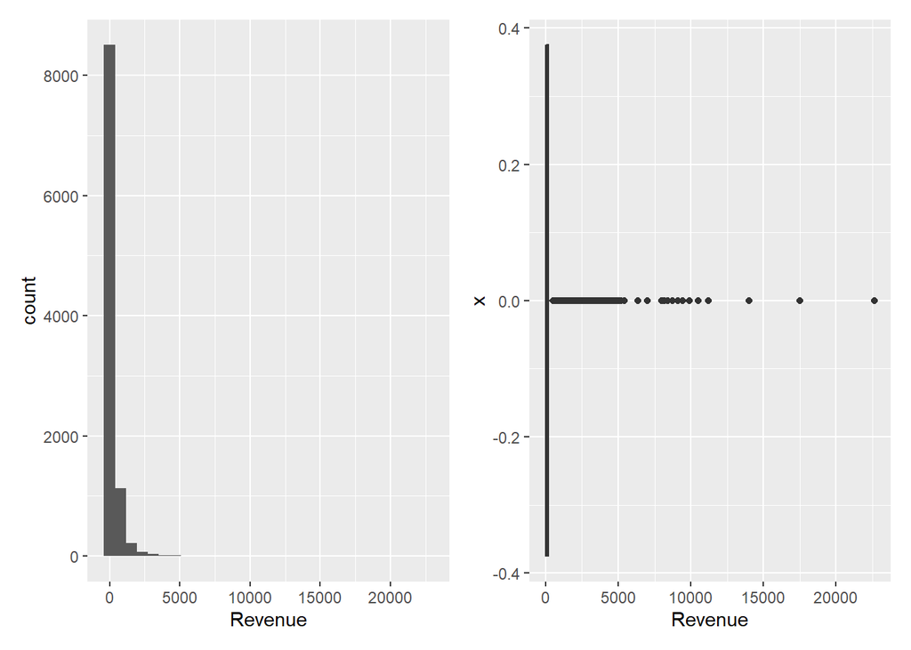

```r
# histogram of revenue
histPlusBox(officeMate, Revenue, 30)
```

**Comments**

- Data is very centered with a right skew
- Many outliers, causing a larger mean to median

### 4.1.2 Discount

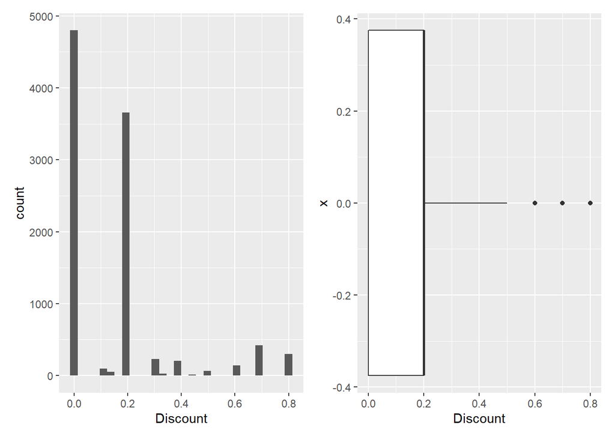

```r
# histogram of discount
histPlusBox(officeMate, Discount, 30)
```

**Comments**

### 4.1.3 Profit

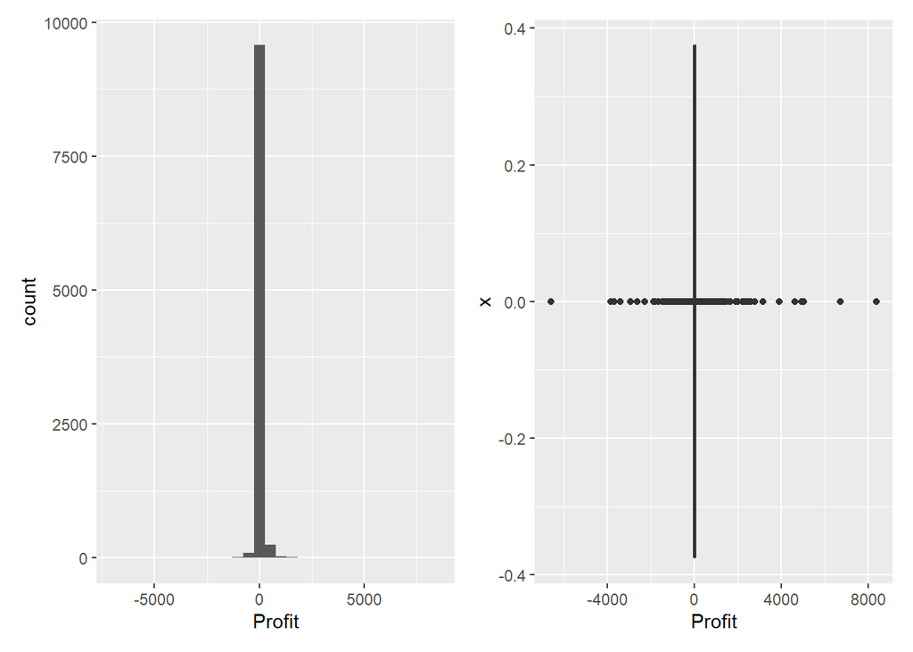

```r
# histogram of profit
histPlusBox(officeMate, Profit, 30)
```

**Comments**

- Profit seems to be symmetrical, with both positive and negative outliers

**Questions**

- How would we better visualize profit?
- Need to consider negative profits

### 4.1.4 Cost

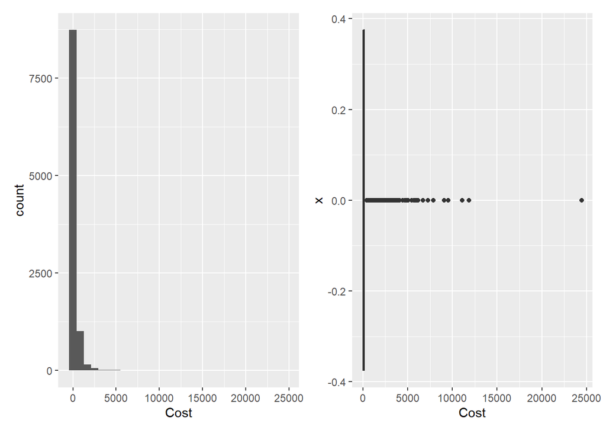

```r
# histogram of Cost
histPlusBox(officeMate, Cost, 30)
```

**Comments**

- Very positively skewed
- Created just to visualize/use later?

## 4.2 Categorical and Factor Variables

### 4.2.1 Ship.Mode

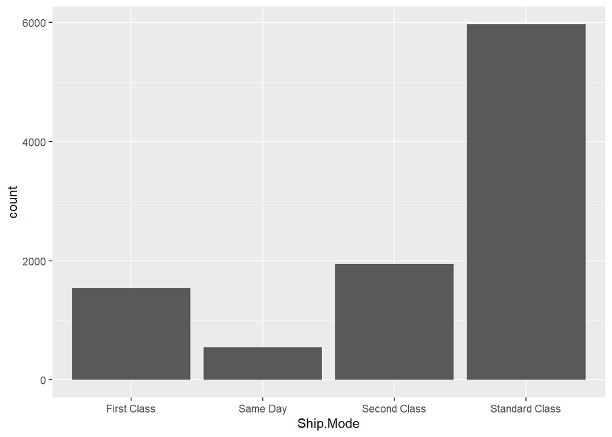

```r
# Bar graph of ship mode
officeMate %>%
  ggplot(mapping = aes(x = Ship.Mode)) +
  geom_bar()
```

**Comments**

- Most customers use the Standard class shipping mode, followed by second class and first class
- There is not a large difference between second and first class

**Questions**

- What could cause standard class to be the most popular mode?
- What other variables may factor into which class is selected?
- Do some regions prefer certain classes?

### 4.2.2 City

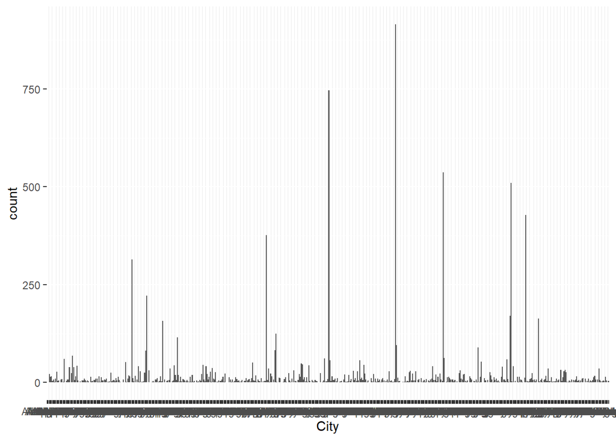

```r
# Bar Graph of cities
# Too many cities to extract any significant meaning
officeMate %>%
  ggplot(mapping = aes(x = City)) +
  geom_bar()
```

**Comments**

- Graph would have to be edited to be relevant

### 4.2.3 State

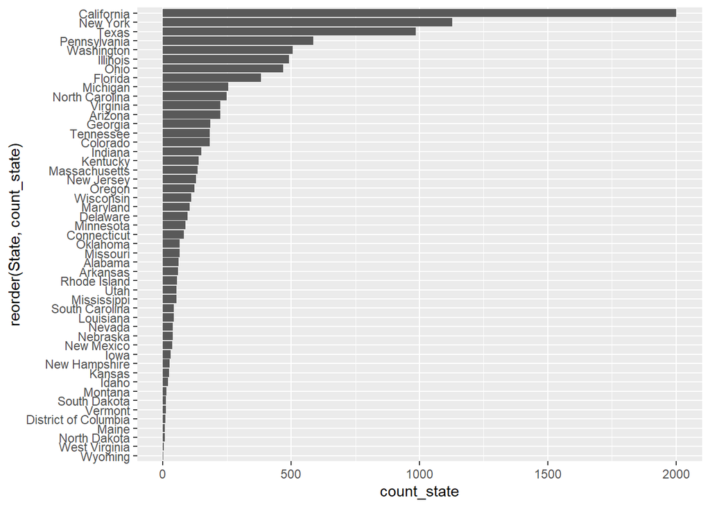

```r
#Bar Graph of states
officeMate %>%
  group_by(State) %>%
  summarize(count_state = n()) %>%
  ggplot(mapping = aes(x = reorder(State, count_state), y = count_state)) +
  geom_bar(stat = "identity") +
  coord_flip()
```

**Comments**

- California has the largest count of customers, followed by New York and Texas
- A single region of the country does not stand out in being the largest or smallest consumer

**Questions**

- Do larger customers receive larger discounts?
- How would you attract smaller customers?
- Need to be more selective about which data to show

### 4.2.4 Region

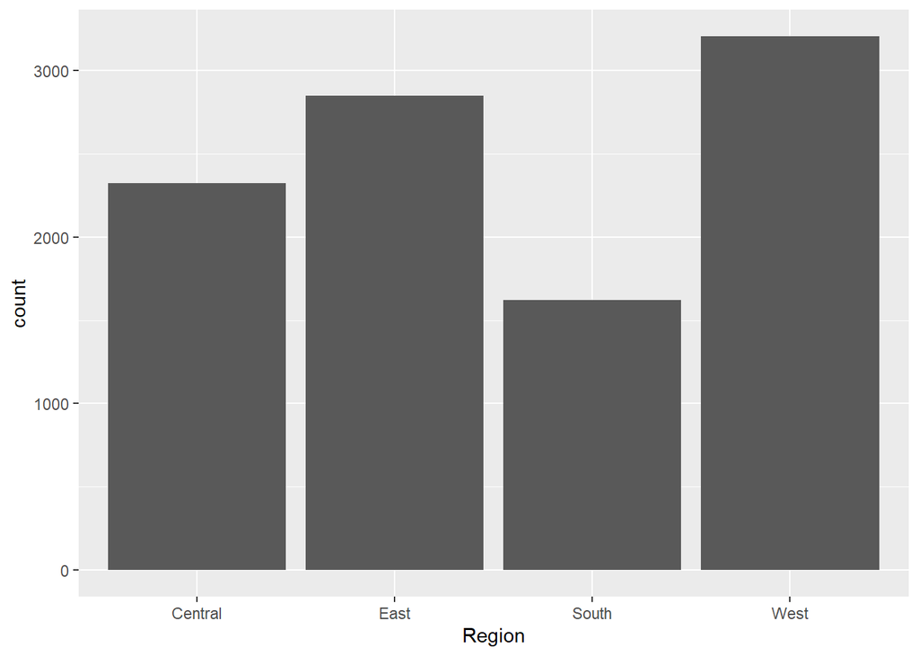

```r
# Bar graph of Region
officeMate %>%
  ggplot(mapping = aes(x = Region)) +
  geom_bar()
```

**Comments**

- The West is the largest customer, probably due to California as seen above
- The South is the smallest customer

**Questions**

- What would increase sales in the South?
- Does the data differ when revenue/profit is considered?

### 4.2.5 Segment

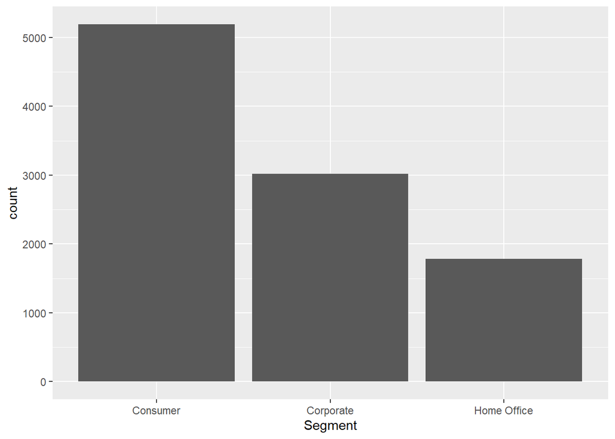

```r
# Bar graph of segment
officeMate %>%
  ggplot(mapping = aes(x = Segment)) +
  geom_bar()
```

**Comments**

- Consumer products have the most sales, followed by corporate and home office

**Question**

- What could increase corporate sales?
  - Do consumer products have more discounts?

### 4.2.6 Category

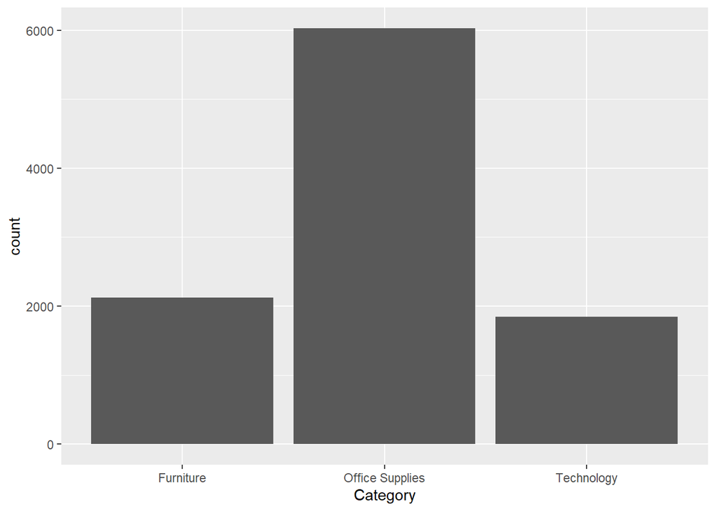

```r
#bar graph of category
officeMate %>%
  ggplot(mapping = aes(x = Category)) +
  geom_bar()
```

**Comments**

- Office supplies have the most sales followed by furniture and technology
- Furniture and technology are almost equally sold

**Questions**

- How would grouping category and segment display different results?

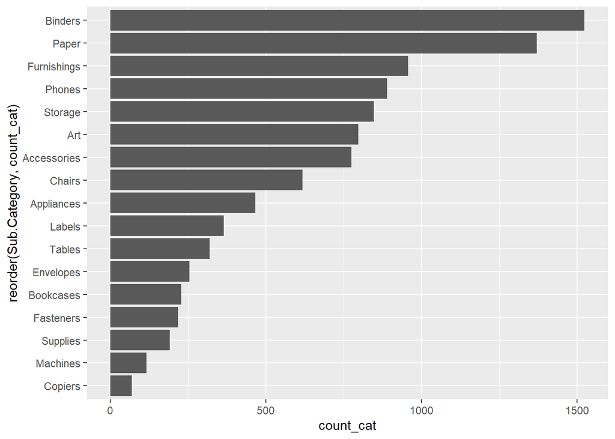

```r
#Bar graph of subcategories
officeMate %>%
  group_by(Sub.Category) %>%
  summarize(count_cat = n()) %>%
  ggplot(mapping = aes(x = reorder(Sub.Category, count_cat), y = count_cat)) +
  geom_bar(stat = "identity") +
  coord_flip()
```

**Comments**

- Binders are the most popular item sold, followed by paper and furnishings

**Questions**

- How would discounts affect the items sold?
- Does revenue/profit show different results?

### 4.2.7 Quantity

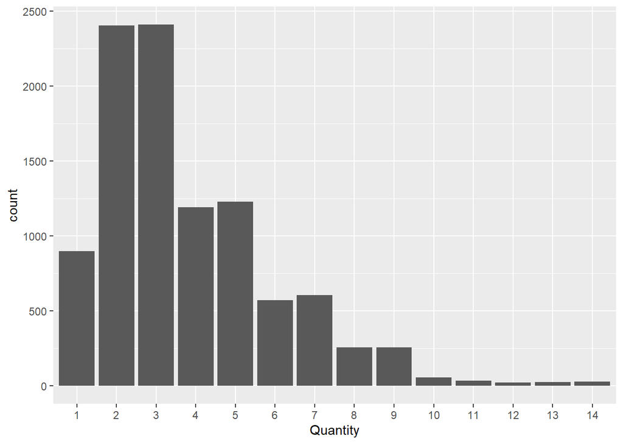

```r
#Bar graph of quantity
 officeMate %>%
  ggplot(mapping = aes(x = Quantity)) +
  geom_bar()
```

**Comments**

- Most customers buy 2 or 3 units of items
- Data is very positively skewed
- Data seems to be grouped, (2,3), (4,5), (6,7) (8,9)

### 4.2.8 Order.Date

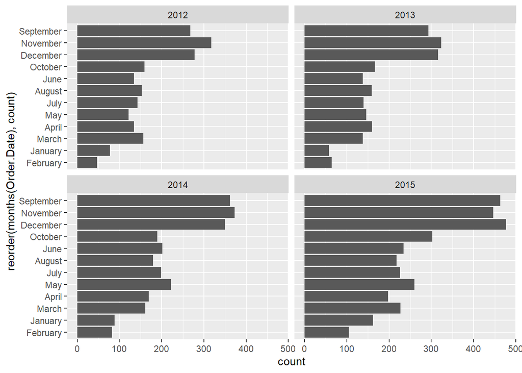

```r
# Faceted graph of order dates over the years
officeMate %>%
  group_by(Order.Date) %>%
  summarize(count = n()) %>%
  ggplot(mapping = aes(x = reorder(months(Order.Date), count), y = count)) +
  geom_col() +
  facet_wrap(~ year(Order.Date)) +
  coord_flip()
```

**Comments**

- Most sales are shown in 2015

**Questions**

- Could we visualize this on one graph?
- Which year was the most profitable?

### 4.2.9 Ship.Date

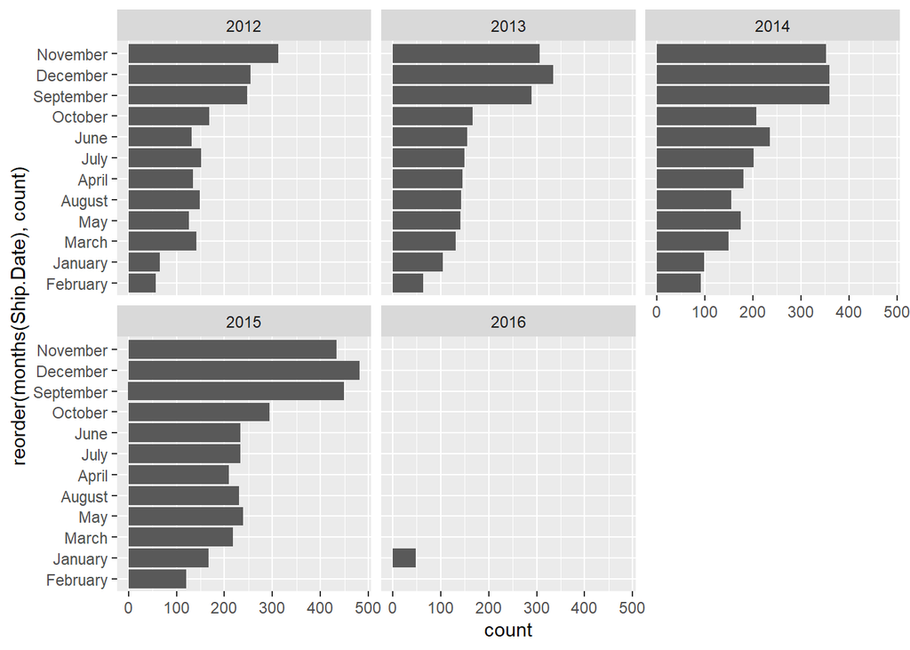

```r
# Faceted graph of shipping dates over the years
officeMate %>%
  group_by(Ship.Date) %>%
  summarize(count = n()) %>%
  ggplot(mapping = aes(x = reorder(months(Ship.Date), count), y = count)) +
  geom_col() +
  facet_wrap(~ year(Ship.Date)) +
  coord_flip()
```

### 4.2.10 Ship Time

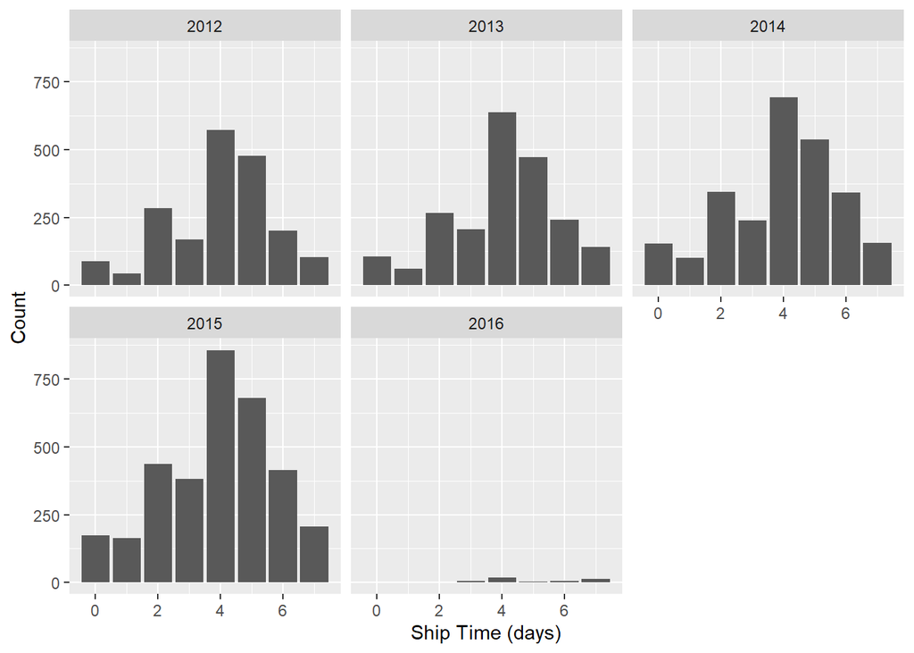

```r
# Faceted graphs of shiptime over the years
officeMate %>%
  group_by(shipTime, Ship.Date) %>%
  summarize(count = n()) %>%
  ggplot(mapping = aes(x = shipTime, count), y = count) +
  geom_col() +
  facet_wrap(~ year(Ship.Date)) +
  labs(x = "Ship Time (days)", y = "Count")
```

**Comments**

- Average shipping date is around 4 days
- Shipping time is consistent almost across all years, except 2016
  - 2016 may have less data

# 5 Multivariate non-graphical analysis

## 5.1 Numeric

### 5.1.1 Correlation Table

```r
# Correlation table of quantitative variables
corTab <- officeMate %>%
  select_if(is.numeric) %>% # Use to select just the numeric variables
  cor() %>%
  round(2)
kable(corTab)
```

|  | Postal.Code | Revenue | Discount | Profit | Cost | shipTime |
| --- | --- | --- | --- | --- | --- | --- |
| Postal.Code | 1.00 | -0.02 | 0.06 | -0.03 | -0.01 | -0.01 |
| Revenue | -0.02 | 1.00 | -0.03 | 0.48 | 0.93 | -0.01 |
| Discount | 0.06 | -0.03 | 1.00 | -0.22 | 0.06 | 0.00 |
| Profit | -0.03 | 0.48 | -0.22 | 1.00 | 0.12 | 0.00 |
| Cost | -0.01 | 0.93 | 0.06 | 0.12 | 1.00 | -0.01 |
| shipTime | -0.01 | -0.01 | 0.00 | 0.00 | -0.01 | 1.00 |

**Comments**

- Very little correlation across the board
- High correlation between cost and revenvue
  - Cost was created using revenue, need to take that into account
- Revenue and profit also have a higher correlation, likely that profit was generated from Revenue

# 6 Multivariate Graphical Analysis

## 6.1 Quantitatives

### 6.1.1 Cost ~ Revenue

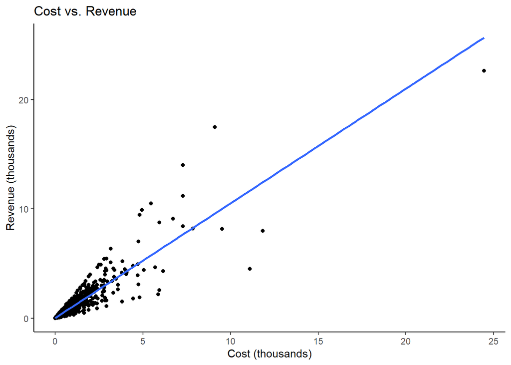

```r
# Scatterplot of cost and revenue, should be positive
officeMate %>%
  ggplot(mapping = aes(x = Cost/1000, y = Revenue/1000)) + #divide cost and revenue for clarity
  geom_point(position = "jitter") +
  geom_smooth(method = lm, se = FALSE) +
  theme_classic() +
  labs(title = "Cost vs. Revenue", x = "Cost (thousands)", y = "Revenue (thousands)")
```

**Comments**

- As expected, positive relationship between Revenue and cost
- Slope is moderate
- symmetrical around the trend line

### 6.1.2 Cost ~ Discount

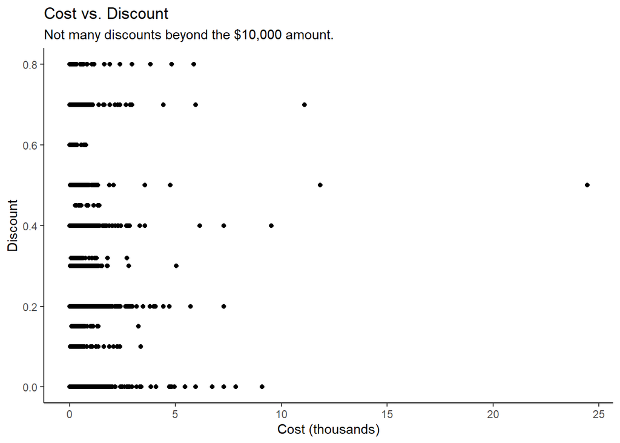

```r
# Scatterplot of costs and discounts
officeMate %>%
  ggplot(mapping = aes(x = Cost/1000, y = Discount)) + #divide cost for clarity
  geom_point() +
  theme_classic() +
  labs(title = "Cost vs. Discount", subtitle = "Not many discounts beyond the $10,000 amount.", x = "Cost (thousands)")
```

### 6.1.3 Discount ~ Revenue

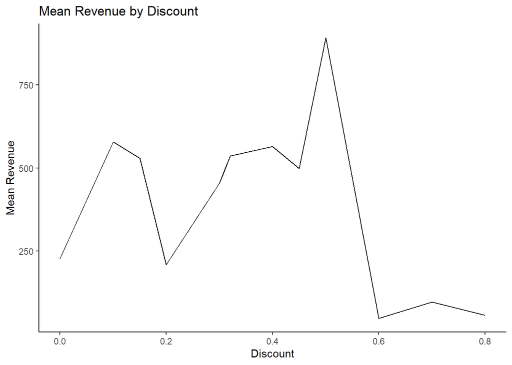

```r
# Using mean as a measure of central tendency because it is much lower than the median suggesting that the data is skewed.
officeMate %>%
  group_by(Discount) %>%
  summarize(meanRev = mean(Revenue)) %>% #using mean revenue
  ggplot(mapping = aes(x = Discount, y = meanRev)) +
  geom_line() +
  theme_classic() +
  labs(title = "Mean Revenue by Discount", x = "Discount", y = "Mean Revenue")
```

**Comments**

- Unsurprisingly low revenue with higher discounts
- 20% discounts have less revenue
- Higher revenue between 0-20% and 30-50%

**Questions**

- Between 30% and 50% seems to be the sweetspot as far as discounts are concerned
- Does higher revenue mean higher profit in this case?

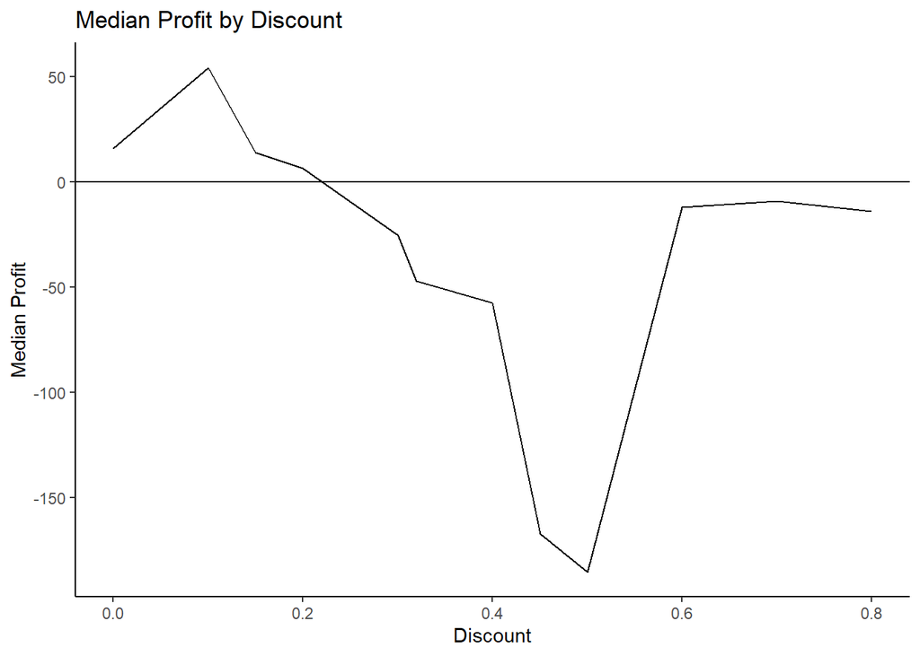

```r
# Using mean as a measure of central tendency because it is much lower than the median suggesting that the data is skewed.
officeMate %>%
  group_by(Discount) %>%
  summarize(medProf = median(Profit)) %>% #using median profit
  ggplot(mapping = aes(x = Discount, y = medProf)) +
  geom_line() +
  geom_hline(yintercept = 0) + #adding a horizontal line to show breakeven point
  theme_classic() +
  labs(title = "Median Profit by Discount", x = "Discount", y = "Median Profit")
```

**Comments**

- Higher revenue does not mean higher discount
- Median profits are positive only when discount is 20% or lower

**Questions**

- How do other factors impact the profit/discount model

### 6.1.4 Revenue ~ Profit

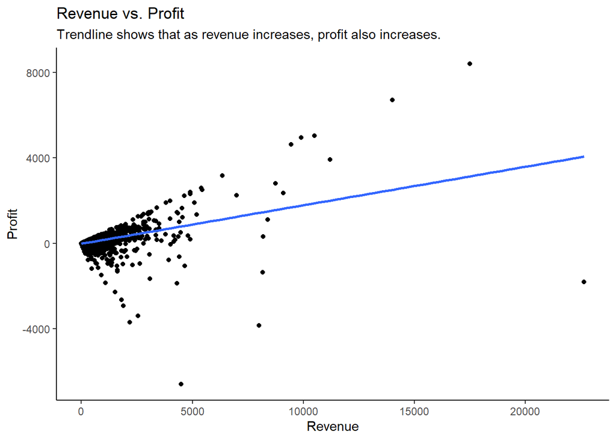

```r
# Creating scatterplot to plot revenue and profit
officeMate %>%
  ggplot(mapping = aes(x = Revenue, y = Profit)) +
  geom_point() +
  geom_smooth(method = lm, se = FALSE) +
  theme_classic() +
  labs(title = "Revenue vs. Profit", subtitle = "Trendline shows that as revenue increases, profit also increases.")
```

**Comments**

- Seems to be a weak correlations between these two variables

## 6.2 Categorical Variables

### 6.2.1 Category ~ Average Discount

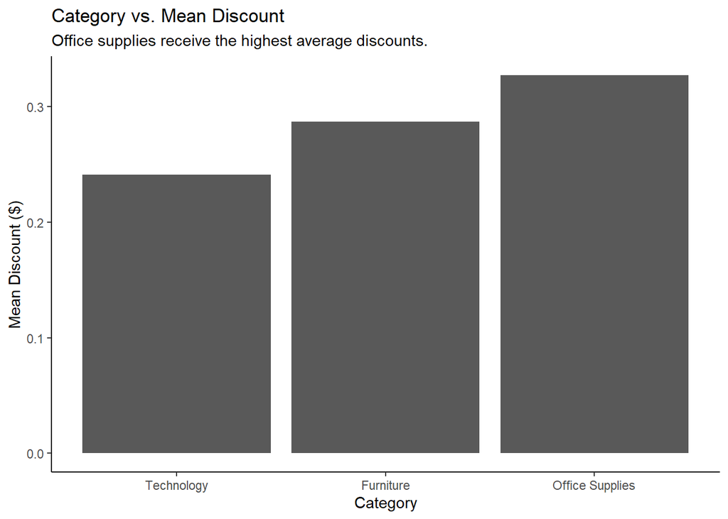

```r
# Graphing categories by the average discount
officeMate %>%
  filter(Discount != 0) %>% #using only discount
  group_by(Category) %>%
  summarize(meanDisc = mean(Discount)) %>% #using means
  ggplot(mapping = aes(x = reorder(Category, meanDisc), y = meanDisc)) +
  geom_col() +
  theme_classic() +
  labs(title = "Category vs. Mean Discount", subtitle = "Office supplies receive the highest average discounts.", x = "Category", y = "Mean Discount ($)")
```

**Comments**

- Higher discounts in office supplies
- Indicates that office supplies may also have lower profits

**Questions**

- Is there a similar trend among the subcategories?

### 6.2.2 Subcategory ~ Discount Count

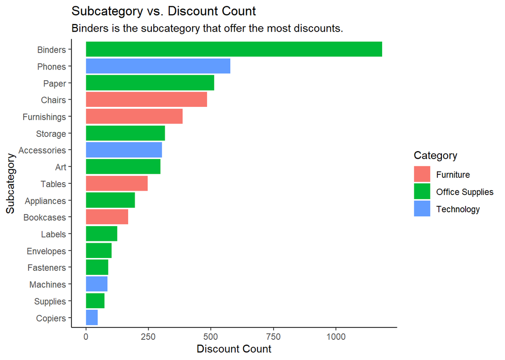

```r
# Graph of Subcategory by the Discount counts
officeMate %>%
  filter(Discount != 0) %>% #using only discounts
  group_by(Sub.Category, Category) %>%
  summarize(count_dis = n()) %>% #creating a count
  ggplot(mapping = aes(x = reorder(Sub.Category, count_dis), y = count_dis, fill = Category)) +
  geom_bar(stat = "identity") +
  coord_flip() +
  theme_classic() +
  labs(title = "Subcategory vs. Discount Count", subtitle = "Binders is the subcategory that offer the most discounts.", x = "Subcategory", y = "Discount Count")
```

**Comments**

- Suprisingly less discounts given on unpopular items
- Discount count may be switched with profit/revenue for more information
- Confirms more discounts given in office supplies

### 6.2.3 Discount Factor Counts

```r
#Factoring Discount to see the summary
disc_factor <- factor(officeMate$Discount)
summary(disc_factor)
```

```
##    0  0.1 0.15  0.2  0.3 0.32  0.4 0.45  0.5  0.6  0.7  0.8
## 4798   94   52 3657  227   27  206   11   66  138  418  300
```

### 6.2.4 Ship Time ~ Ship Mode

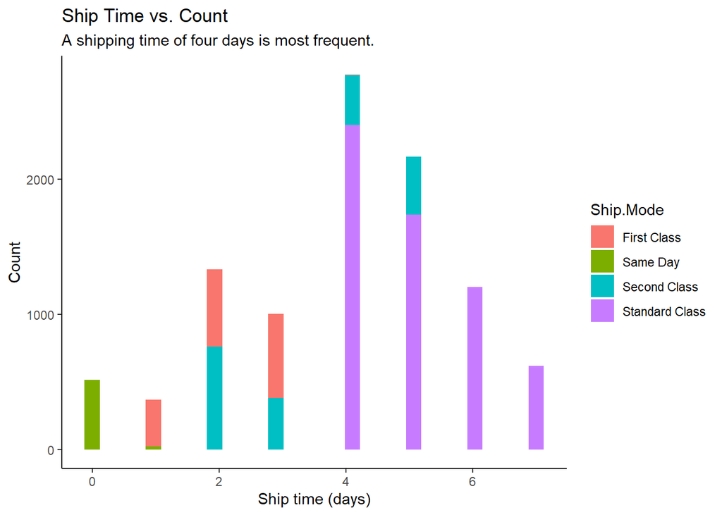

```r
# Showing ship mode breakdown by days
# Allows us to see how long ship modes really take
officeMate %>%
  ggplot(mapping = aes(x = shipTime, fill = Ship.Mode)) +
  geom_histogram() +
  theme_classic() +
  labs(title = "Ship Time vs. Count", subtitle = "A shipping time of four days is most frequent.", x = "Ship time (days)", y = "Count")
```

**Comments**

- Data makes sense
- Standard class does not have ship times below the four day mark.
- Little difference between first class and second class
- Standard class could be popular because it is likely to be within 5 business days

**Questions**

- Difference between first and second class?
- One would think that first class has higher amounts of lower ship times, right?
  - Compared to second class

### 6.2.5 Ship.Mode ~ Median Revenue

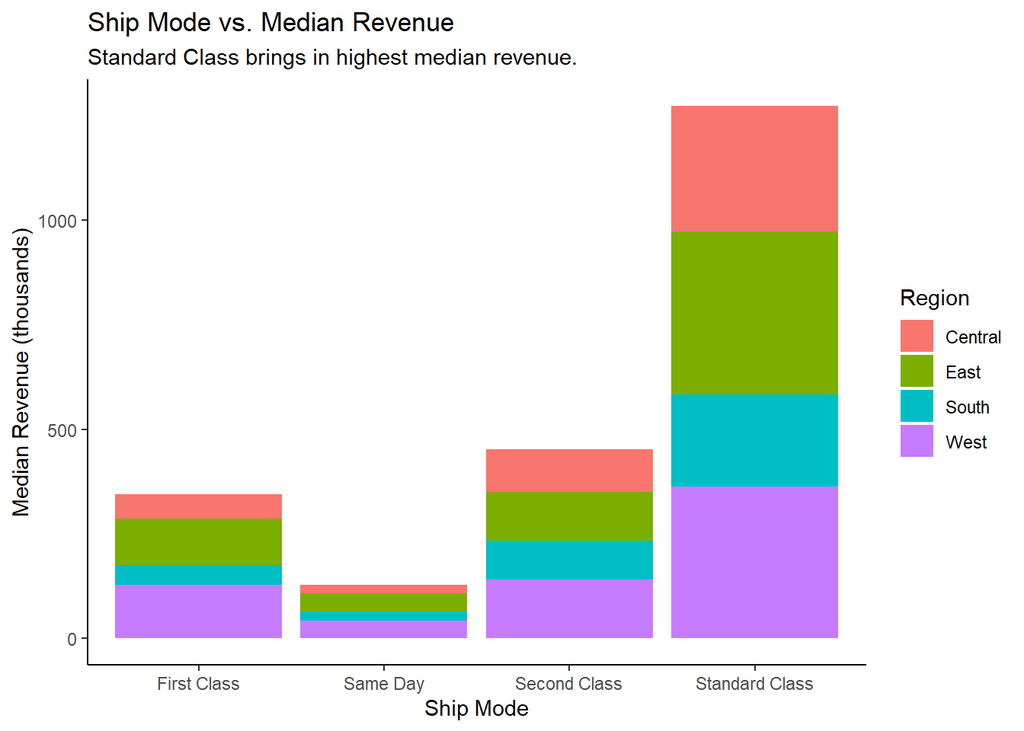

```r
# Showing ship mode breakdown by Region and Median Rev
officeMate %>%
  group_by(Ship.Mode, Revenue, Region) %>%
  summarize(medRev = median(Revenue)) %>% #using median revenue
  ggplot(mapping = aes(x = reorder(Ship.Mode, medRev), y = medRev/1000, fill = Region)) +
  geom_col() +
  theme_classic() +
  labs(title = "Ship Mode vs. Median Revenue", subtitle = "Standard Class brings in highest median revenue.", x = "Ship Mode", y = "Median Revenue (thousands)")
```

**Comments**

- Proportion of regions across ship modes seems consistent
- Overall, standard class is preferred across all regions

### 6.2.6 Time ~ Mean Ship Time

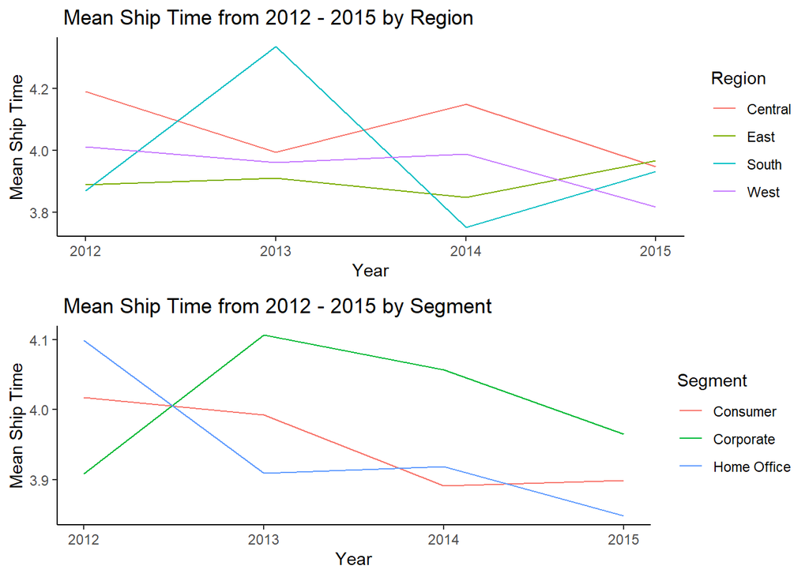

```r
#Creating two graphs to view average shipping times by region and segment over time
grid.arrange(
  officeMate %>%
    mutate(yr = year(Order.Date)) %>%
    group_by(yr, Region) %>%
    summarise(mean_st = mean(shipTime)) %>% #using mean
    ggplot(aes(x = yr, y = mean_st, group = Region, color = Region)) +
    geom_line() +
    theme_classic() +
    labs(title = " Mean Ship Time from 2012 - 2015 by Region", x = "Year", y = "Mean Ship Time"),

  officeMate %>%
    mutate(yr = year(Order.Date)) %>%
    group_by(yr, Segment) %>%
    summarise(mean_st = mean(shipTime)) %>% #using mean
    ggplot(aes(x = yr, y = mean_st, group = Segment, color = Segment)) +
    geom_line() +
    theme_classic() +
    labs(title = " Mean Ship Time from 2012 - 2015 by Segment", x = "Year", y = "Mean Ship Time")
)
```

**Comments**

- South has an almost inverse trend compared to other regions
  - Large spike in ship time in 2013, large decrease in 2014
  - East follows a similar pattern
- West and Central have similar trends
  - Lower ship time in 2013, spike in 2014, and now lower ship times
- Corporate has the largest mean ship time but is decreasing
- Consumer ship time is slightly increasing after 2014 after a large decrease
- Home office has an inverse trend to consumer ship times

### 6.2.7 Segment ~ Region

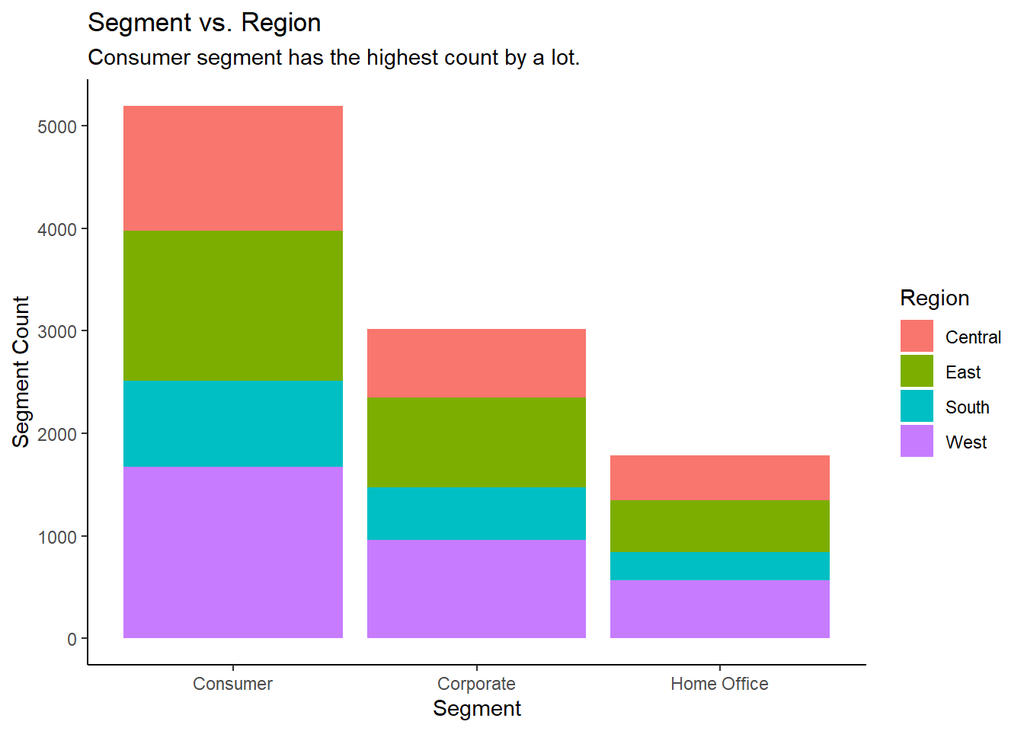

```r
# Creating a graph to view Region breakdown by segment
officeMate %>%
  group_by(Region, Segment) %>%
  summarize(count1 = n()) %>%
  ggplot(mapping = aes(x = Segment, y = count1, fill = Region)) +
  geom_col() +
  theme_classic() +
  labs(title = "Segment vs. Region", subtitle = "Consumer segment has the highest count by a lot.", y = "Segment Count")
```

**Comments**

- Proportions of regions to segments is steady across each segment
- Data is not surprising

### 6.2.8 Weekday ~ Orders

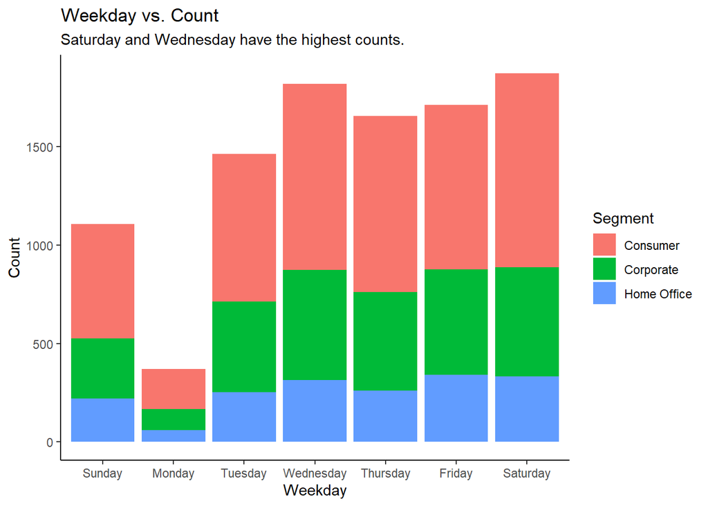

```r
day_week <- c("Sunday", "Monday", "Tuesday", "Wednesday", "Thursday", "Friday", "Saturday") #creating a vector to create days

#Creating graph to view orders by day
officeMate %>%
  mutate(orderDay = weekdays(Order.Date)) %>%
  mutate(orderDay = fct_relevel(orderDay, levels = day_week)) %>% #refactoring days
  ggplot(mapping = aes(x = orderDay, fill = Segment)) + #visualize by segment
  geom_bar() +
  theme_classic() +
  labs(title = "Weekday vs. Count", subtitle = "Saturday and Wednesday have the highest counts.", x = "Weekday", y = "Count")
```

**Comments**

- Surprised at the balance between Tuesday to Saturday
- Lowest amount of orders monday
- Proportion of segments matches their respective counts as seen in earlier graphs

**Questions**

- Why is Monday so low?

### 6.2.9 Year ~ Median Profit

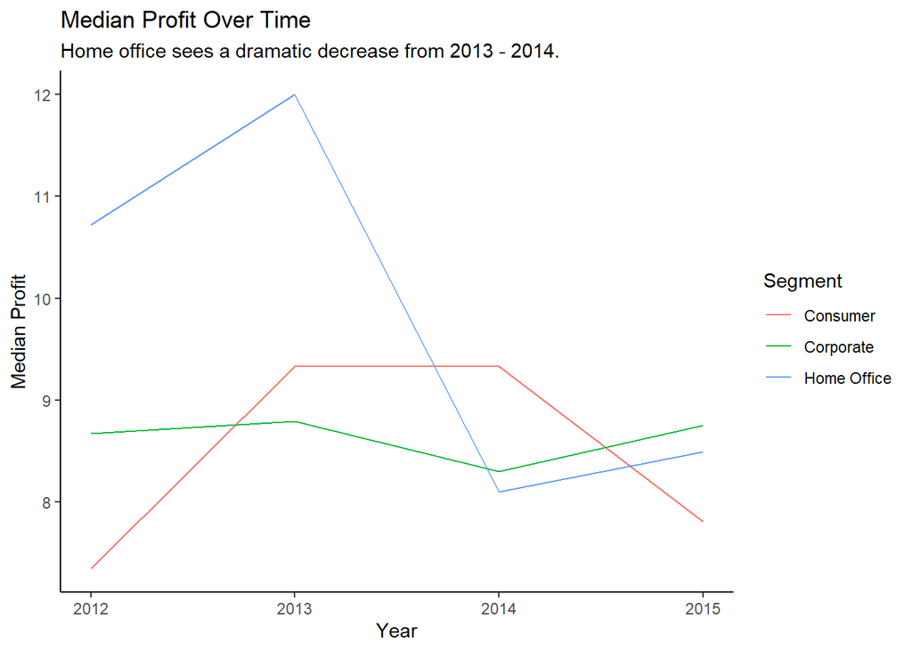

```r
# Profit data is skewed, so we used median instead of mean
officeMate %>%
  mutate(yr = year(Order.Date)) %>%
  group_by(Segment, yr) %>%
  summarise(med_prof = median(Profit)) %>%  #using median profit
  ggplot(mapping = aes(x = yr, y = med_prof, color = Segment)) +    #separating by segment
  geom_line() +
  theme_classic() +
  labs(title = "Median Profit Over Time", subtitle = "Home office sees a dramatic decrease from 2013 - 2014.", x = "Year", y = "Median Profit")
```

**Comments**

- Decreasing consumer profit after 2014 despite being the largest segment
- Drastic decrease in median profit for home office from 2013-2014

**Questions**

- Does the revenue trend over time look similar?
  - Does the decrease in home office profit reflect in revenue?

### 6.2.10 Total Revenue/Profit ~ State

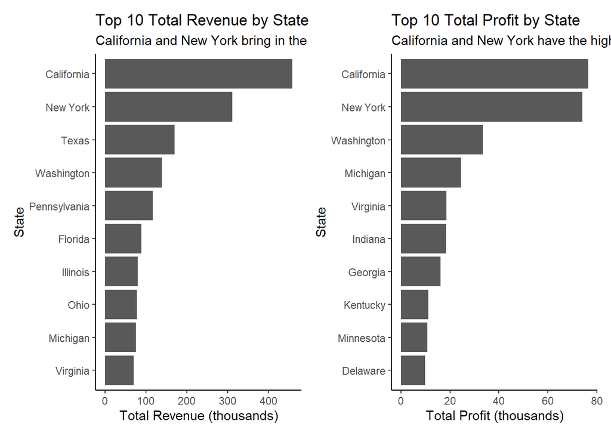

```r
graph1 <- officeMate %>%
  group_by(State) %>%
  summarize(totalRev = sum(Revenue)) %>%
  top_n(10, totalRev) %>% #using top 10 to show highest revenue states
  ggplot(mapping = aes(x = reorder(State, totalRev), y = totalRev/1000)) +
  geom_col() +
  coord_flip() +
  theme_classic() +
  labs(title = "Top 10 Total Revenue by State", subtitle = "California and New York bring in the most total revenue.", x = "State", y = "Total Revenue (thousands)")

graph2 <- officeMate %>%
  group_by(State) %>%
  summarize(totalProf = sum(Profit)) %>%
  top_n(10, totalProf) %>% #using top 10 to show highest revenue states
  ggplot(mapping = aes(x = reorder(State, totalProf), y = totalProf/1000)) +
  geom_col()+
  coord_flip() +
  theme_classic() +
  labs(title = "Top 10 Total Profit by State", subtitle = "California and New York have the highest profits.", x = "State", y = "Total Profit (thousands)")

graph1 + graph2
```

**Comments**

- Not too much difference in the revenue and profit
- Differences could lie in higher costs for certain states

**Questions**

- Does NYC have a high cost?

### 6.2.11 Total Cost ~ State

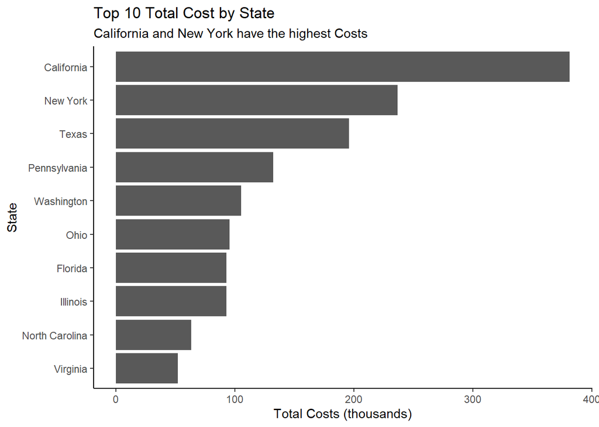

```r
# Cost breakdown per top ten states
officeMate %>%
  group_by(State) %>%
  summarize(totalCost = sum(Cost)) %>%
  top_n(10, totalCost) %>% #using top 10 to show highest cost states
  ggplot(mapping = aes(x = reorder(State, totalCost), y = totalCost/1000)) +
  geom_col()+
  coord_flip() +
  theme_classic() +
  labs(title = "Top 10 Total Cost by State", subtitle = "California and New York have the highest Costs", x = "State", y = "Total Costs (thousands)")
```

**Comments**

- NY does have a high cost but not more than California
- Washington does have a low cost, reflecting in the profit

### 6.2.12 Total Revenue/Profit ~ City

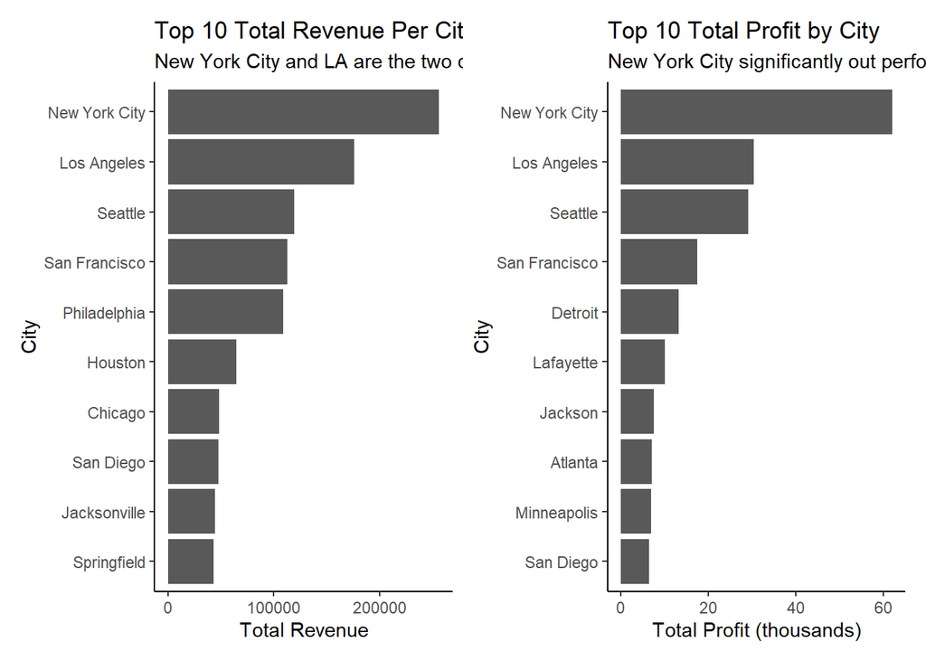

```r
# Top ten total revenue and city per city
cityGraph <- officeMate %>%
  group_by(City) %>%
  summarize(totalRev = sum(Revenue)) %>% #using total revenue
  top_n(10, totalRev) %>% #using top 10 to show highest revenue cities
  ggplot(mapping = aes(x = reorder(City, totalRev), y = totalRev)) +
  geom_col() +
  coord_flip() +
  theme_classic() +
  labs(title = "Top 10 Total Revenue Per City", subtitle = "New York City and LA are the two cities that pull in the most revenue.", x = "City", y = "Total Revenue")

cityGraph2 <- officeMate %>%
  group_by(City) %>%
  summarize(totalProf = sum(Profit)) %>% #using total profits
  top_n(10, totalProf) %>% #using top 10 to show highest profits cities
  ggplot(mapping = aes(x = reorder(City, totalProf), y = totalProf/1000)) +
  geom_col()+
  coord_flip() +
  theme_classic() +
  labs(title = "Top 10 Total Profit by City", subtitle = "New York City significantly out performs the other nine locations.", x = "City", y = "Total Profit (thousands)")

cityGraph + cityGraph2
```

**Comments**

- NYC has a larger revenue than LA, probably contributing to the state’s large revenue
- LA has a lower profit compared to their revenue, perhaps from a very high cost

**Questions**

- How does NYC and LA’s costs reflect their revenue and profit?